# Tutorial for main functions in SurrogateParadoxTest package

# Main Functions

We will go through an example using the main functions in the **SurrogateParadoxTest** package. First, install the package from CRAN and load it. This package imports the **MonotonicityTest** package; if you see error messages about a fortran compiler, please see: https://cran.r-project.org/bin/macosx/tools/ We also load **ggplot2** for plots made later in the document.

```r
# install.packages('SurrogateParadoxTest')
library(SurrogateParadoxTest)
library(ggplot2)
```

This package provides functions to nonparametrically assess assumptions necessary to prevent the surrogate paradox through hypothesis tests of stochastic dominance, monotonicity of regression functions, and non-negative residual treatment effects. More details will be available in Hsiao, Tian, Parast (2025) “Avoiding the Surrogate Paradox: An Empirical Framework for Assessing Assumptions” (under review).

The main function is **test_assumptions** which tests the 3 assumptions that are sufficient to prevent the surrogate paradox: (1) stochastic dominance of surrogate values in the treatment group over control group, (2) monotonicity of the relationship between the surrogate and the primary outcome in both treatment and control groups, and (3) a non-negative residual treatment effect.

The necessary inputs are **s0**, the vector of surrogate marker values in the control group, **s1**, the vector of surrogate marker values in the treated group, **y0**, the vector of primary outcome values in the control group, and **y1**, the vector of primary outcome values in the treated group. Let’s make some data, but if you have your own data, use your own data to define objects that will be used for the s0, s1, y0, y1 arguments.

```r
# set seed so we get the same result
set.seed(1)
sample.size = 500
# generate surrogate marker in control group
s_c <- rnorm(sample.size, 3, 1)
# defining a function of s in the control group
m_c <- function(s) 1 + 1 * s
# generate primary outcome in the control group
y_c <- sapply(s_c, function(s) rnorm(1, m_c(s), 1))

# generate surrogate marker in treated group
s_t <- rnorm(sample.size, 4, 1)
# defining a function of s in the treated group
m_t <- function(s) 2 + 3 * s
# generate primary outcome in the treated group
y_t <- sapply(s_t, function(s) rnorm(1, m_t(s), 1))
```

The default is to run all 3 tests (**type = “all”**). However the user can specify only 1 of the tests by specifying **type = “sd”** for the stochastic dominance assumption, **type = “monotonicity”** for the monotonicity assumption, and **type = “nnr”** for the non-negative residual treatment effect assumption.

Let’s start with just testing stochastic dominance. We will use **all_results=FALSE** which says to only give the result indicating whether the assumption holds or not (omitting all the other details).

```r
test_assumptions(s0 = s_c, y0 = y_t, s1 = s_t, y1 = y_t, type = "sd",
    all_results = FALSE)
```

```
## [1] "Stochastic dominance assumption: Holds"
```

Here, the results of the test indicate that the stochastic dominance assumption holds. Now let’s ask for all the details.

```r
test_assumptions(s0 = s_c, y0 = y_c, s1 = s_t, y1 = y_t, type = "sd",
    all_results = TRUE)
```

```
## $result
## [1] "Stochastic dominance assumption: Holds"
##
## $sd_result
## $sd_result$s_hat
## [1] 0
##
## $sd_result$p.value
## [1] 1
##
## $sd_result$reject
## [1] FALSE
```

Truth be told, these won’t make sense without seeing the manuscript. But essentially, the null hypothesis of the test is that the stochastic dominance assumption does hold. The alternative is that it is does not hold i.e., there exists some s where dominance does not hold. This gives the value of our test statistic **s_hat**, the p-value from testing this null hypothesis **p.value**, and whether we reject the null hypothesis **reject**.

Now let’s test montonicity; this does involve resampling, so set the seed so your results are reproducible. This function used to be computationally inefficient but we now depend on and use the **MonotonicityTest** package which is much faster. Below, we set the number of bootstrap samples to 200 i.e., **monotonicity_bootstrap_n=200**.

```r
set.seed(12)
test_assumptions(s0 = s_c, y0 = y_c, s1 = s_t, y1 = y_t, type = "monotonicity",
    all_results = FALSE, monotonicity_bootstrap_n = 200)
```

```
##   Assumption                            Result
## 1 "Monotonicity assumption (control)"   "Holds"
## 2 "Monotonicity assumption (treatment)" "Holds"
```

These results show that the test indicates that the montonicity assumption holds in both groups.

Now let’s test the non-negative residual treatment effect assumption. This also involves bootstrap resampling, so set the seed so your results are reproducible.

```r
set.seed(1)
test_assumptions(s0 = s_c, y0 = y_c, s1 = s_t, y1 = y_t, type = "nnr",
    all_results = FALSE)
```

```
## [1] "Non-negative residual treatment effect assumption: Holds"
```

The test indicates that the non-negative residual treatment effect assumption holds here.

To test them all, and get all the results, use **type = “all”** or leave unspecified since “all” is the default:

```r
set.seed(1)
test_assumptions(s0 = s_c, y0 = y_c, s1 = s_t, y1 = y_t, type = "all",
    all_results = FALSE, monotonicity_bootstrap_n = 200)
```

```
##   Assumption                               Result
## 1 "Stochastic dominance assumption"        "Holds"
## 2 "Monotonicity assumption (control)"      "Holds"
## 3 "Monotonicity assumption (treatment)"    "Holds"
## 4 "Non-negative residual treatment effect" "Holds"
```

The package only exports the **test_assumptions** function. But there are many internal functions you may find useful. To get them, use three colons for example **SurrogateParadoxTest:::smoother_fitter()**.

# Visualizations

Next, we create visualizations that may be helpful as you test these assumptions. Below, we plot the empirical cdfs of the surrogate in each group, useful for assessing stochastic dominance. Generally, when stochastic dominance holds, we should see the red line at or above the blue line for the entire support.

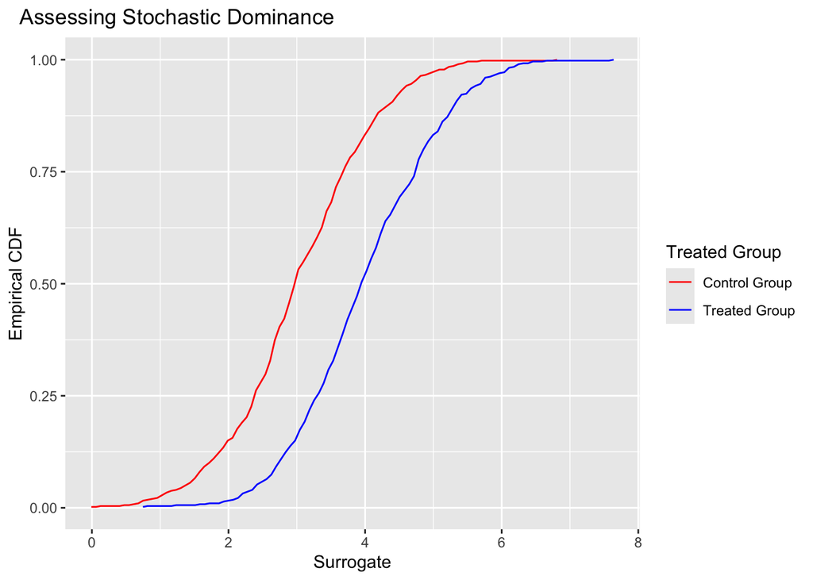

```r
library(ggplot2)

# Empirical CDFs
F0 <- ecdf(s_c)
F1 <- ecdf(s_t)

# Define the ranges for each group
s_c_range <- range(s_c)
s_t_range <- range(s_t)

# Define an extended range for x-axis
s_lower <- min(s_c_range[1], s_t_range[1])
s_upper <- max(s_c_range[2], s_t_range[2])
interval <- (s_upper - s_lower) * 0.08
s_lower <- s_lower - interval
s_upper <- s_upper + interval

# Create the data frame for plotting
data_c <- data.frame(x = seq(s_c_range[1], s_c_range[2], length.out = 100))
data_t <- data.frame(x = seq(s_t_range[1], s_t_range[2], length.out = 100))

# Add y values for the empirical CDFs
data_c$y <- F0(data_c$x)
data_t$y <- F1(data_t$x)

# Create the plot
p <- ggplot() + geom_line(data = data_c, aes(x = x, y = y, colour = "red")) +
    geom_line(data = data_t, aes(x = x, y = y, colour = "blue")) +
    scale_colour_identity("Treated Group", guide = "legend",
        labels = c("Control Group", "Treated Group"), breaks = c("red",
            "blue")) + ylab("Empirical CDF") + xlab("Surrogate") +
    ggtitle("Assessing Stochastic Dominance") + theme(plot.title = element_text(hjust = -0.175))

p
```

For monotonicity, the function used within our package calls a function within the **MonotonicityTest** which creates a plot with intervals flagged as violating monotonicity shown in red. We illustrate this by generating new data where the assumption is violated in a small region of the support and directly calling the internal function. The flagged points are referred to as the Critical Interval.

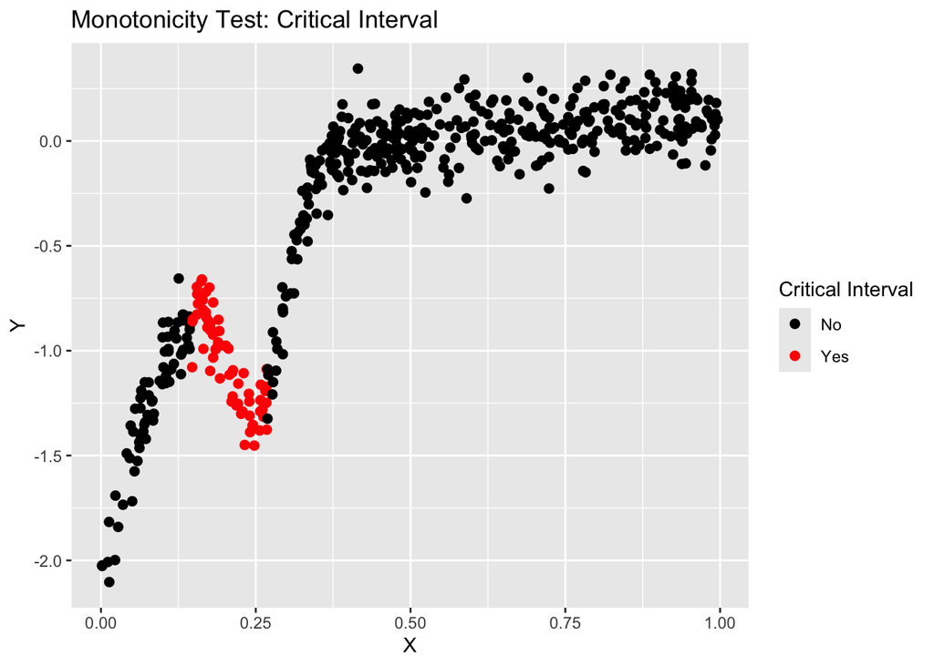

```r
set.seed(1)
sample.size = 500
# making new data where the assumption is violated
g_1 <- function(x, M) {
    if (x <= 0.5) {
        15 * (x - 0.5)^3 + M * (x - 0.5)
    } else {
        M * (x - 0.5)
    }
}
g_2 <- function(x) exp(-250 * (x - 0.25)^2)
make_g <- function(M) {
    f <- function(x) g_1(x, M) - g_2(x)
    return(f)
}
g <- make_g(0.3)
s_new = runif(sample.size)
y_new <- sapply(s_new, function(x_i) rnorm(1, g(x_i), 0.1))

# apply test
mon_result = MonotonicityTest::monotonicity_test(X = s_new, Y = y_new)

# creates plot
mon_result$plot
```

```r
# p-value for test; p<0.05 indicates that the assumption
# does not hold
mon_result$p
```

```
## [1] 0
```

Lastly, we plot the estimated smoothed conditional mean functions in each group, useful for assessing the NNR assumption. Generally, when the assumption holds, we should see the blue line at or above the red line for the entire support.

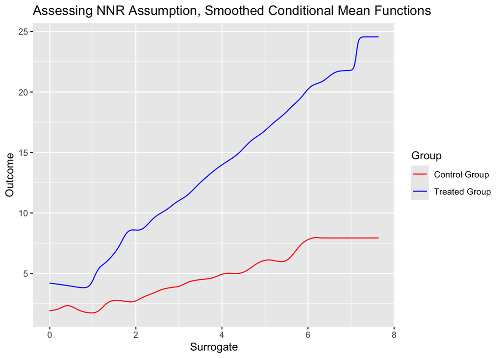

```r
# Define an extended range for x-axis
s_lower <- min(min(s_c), min(s_t))
s_upper <- max(max(s_c), max(s_t))

# Calculating conditional mean function
f0 <- SurrogateParadoxTest:::smoother_fitter(s_c, y_c, h = SurrogateParadoxTest:::calculate_bandwidth(s_c))
f1 <- SurrogateParadoxTest:::smoother_fitter(s_t, y_t, h = SurrogateParadoxTest:::calculate_bandwidth(s_t))

# Constructing data frame for plotting
s_grid <- seq(s_lower, s_upper, length.out = 1000)
yhat0 <- sapply(s_grid, f0)
yhat1 <- sapply(s_grid, f1)
smoothed_df <- as.data.frame(cbind(s = s_grid, yhat0, yhat1))

# Plotting conditional mean functions
p <- ggplot(smoothed_df) + geom_path(aes(x = s, y = yhat0, color = "Control Group")) +
    geom_path(aes(x = s, y = yhat1, color = "Treated Group")) +
    ylab("Outcome") + xlab("Surrogate") + ggtitle("Assessing NNR Assumption, Smoothed Conditional Mean Functions") +
    scale_colour_manual(name = "Group", values = c(`Control Group` = "red",
        `Treated Group` = "blue"))
p
```

That’s all for now!